# Giselle

Der Wunsch, geisterhaft schwebende Elfenwesen auf der Bühne darzustellen, war es, der die Choreographen im 19. Jahrhundert dazu brachte, den Bühnentanz tatsächlich auf die Spitze zu treiben. In zumeist unheimlichen Szenerien trieben tanzende Feenwesen ihr Unwesen.

In GISELLE sind es die tanzsüchtigen Wilis, um die sich das Libretto rankt. Wilis sind Elfenwesen, die als Bräute noch vor ihrer Hochzeit gestorben sind, weil ihre Liebe verraten wurde. Der empfindsamen Giselle ergeht es genauso, denn sie liebt nicht nur das Tanzen, sondern auch Albrecht, der sie umwirbt, obwohl er bereits einer anderen versprochen ist. Als sie die Wahrheit erfährt, verliert sie den Verstand und stirbt. Giselle wird in die Gemeinschaft der Wilis aufgenommen und ist nun wie ihre Gefährtinnen dazu verdammt, die Männer in der Nacht zum Tanzen zu verführen, bis sie sterben. Darüber wacht Myrtha, die Königin der Wilis. Auch Albrecht kommt in den Wald, um Giselles Grab zu besuchen.

## Termine

So. 18. September 2022 14.30 Uhr

[Staatsoper Unter den Linden](https://www.staatsoper-berlin.de/de/ihr-besuch/anfahrt/staatsoper-unter-den-linden.35/)

Dauer: 140 Minuten inkl. 1 Pause

Als Vorbereitung auf den Vorstellungsbesuch werden die Handlung erzählt, wichtige Rollen vorgestellt und kurze Tanzszenen einstudiert.

Nur in Verbindung mit dem Besuch der Familienvorstellung buchbar.

Uhrzeit: 12:30 Uhr

Ort: Staatsoper Unter den Linden

Kosten: 5 €

ANMELDUNG ERFORDERLICH

Telefon: 030 34 384-166

E-Mail: contact@tanz-ist-klasse.de

## Besetzung

- Choreographie und Inszenierung: Patrice Bart nach Jean Coralli und Jules Perrot
- Musik: Adolphe Adam
- Bühne und Kostüme: Peter Farmer
- Dramaturgie: Dr. Christiane Theobald
- Einstudierung: Raffaella Renzi
- Musikalische Leitung: Paul Connelly
- Es spielt: Staatskapelle Berlin
- Giselle: Ksenia Ovsyanick
- Albrecht: David Soares
- Myrtha: Vera Segova
- Hilarion: Alexei Orlenco
- Bauern-Pas-de-deux: Yuria Isaka
- Bauern-Pas-de-deux: Dominic Whitbrook
- Solist:innen und Corps de ballet des Staatsballetts Berlin

## Medien

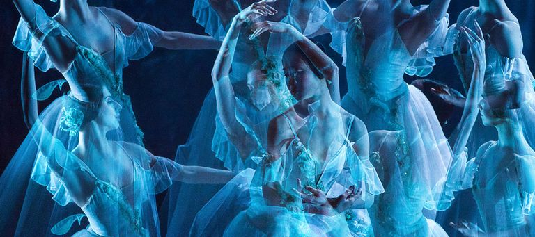